# Risk Factor Analysis

## Outcome Variable

**Outcome Variable:** sstunted

## Predictor Variables

**Intervention Variable:** nhh

**Adjustment Set:**

unadjusted

## Stratifying Variables

The analysis was stratified on these variable(s):

- agecat
- studyid

The following strata were considered:

- agecat: 12 months, studyid: ki1000108-IRC
- agecat: 12 months, studyid: ki1000304b-SAS-FoodSuppl
- agecat: 12 months, studyid: ki1017093-NIH-Birth
- agecat: 12 months, studyid: ki1017093b-PROVIDE
- agecat: 12 months, studyid: ki1017093c-NIH-Crypto
- agecat: 12 months, studyid: ki1148112-LCNI-5
- agecat: 18 months, studyid: ki1000108-IRC
- agecat: 18 months, studyid: ki1000304b-SAS-FoodSuppl
- agecat: 18 months, studyid: ki1017093-NIH-Birth
- agecat: 18 months, studyid: ki1017093b-PROVIDE
- agecat: 18 months, studyid: ki1017093c-NIH-Crypto
- agecat: 18 months, studyid: ki1148112-LCNI-5
- agecat: 24 months, studyid: ki1000108-IRC
- agecat: 24 months, studyid: ki1017093-NIH-Birth
- agecat: 24 months, studyid: ki1017093b-PROVIDE
- agecat: 24 months, studyid: ki1017093c-NIH-Crypto
- agecat: 24 months, studyid: ki1148112-LCNI-5
- agecat: 3 months, studyid: ki1000108-IRC
- agecat: 3 months, studyid: ki1000304b-SAS-FoodSuppl
- agecat: 3 months, studyid: ki1017093-NIH-Birth
- agecat: 3 months, studyid: ki1017093b-PROVIDE
- agecat: 3 months, studyid: ki1017093c-NIH-Crypto
- agecat: 6 months, studyid: ki1000108-IRC
- agecat: 6 months, studyid: ki1000304b-SAS-FoodSuppl
- agecat: 6 months, studyid: ki1017093-NIH-Birth
- agecat: 6 months, studyid: ki1017093b-PROVIDE
- agecat: 6 months, studyid: ki1017093c-NIH-Crypto
- agecat: 6 months, studyid: ki1148112-LCNI-5
- agecat: 9 months, studyid: ki1000108-IRC
- agecat: 9 months, studyid: ki1000304b-SAS-FoodSuppl
- agecat: 9 months, studyid: ki1017093-NIH-Birth
- agecat: 9 months, studyid: ki1017093b-PROVIDE
- agecat: 9 months, studyid: ki1017093c-NIH-Crypto
- agecat: 9 months, studyid: ki1148112-LCNI-5
- agecat: Birth, studyid: ki1000108-IRC
- agecat: Birth, studyid: ki1017093-NIH-Birth
- agecat: Birth, studyid: ki1017093c-NIH-Crypto

### Dropped Strata

Some strata were dropped due to rare outcomes:

- agecat: Birth, studyid: ki1000108-IRC
- agecat: Birth, studyid: ki1017093-NIH-Birth
- agecat: Birth, studyid: ki1017093c-NIH-Crypto
- agecat: 3 months, studyid: ki1000108-IRC
- agecat: 3 months, studyid: ki1000304b-SAS-FoodSuppl
- agecat: 3 months, studyid: ki1017093-NIH-Birth
- agecat: 3 months, studyid: ki1017093b-PROVIDE
- agecat: 3 months, studyid: ki1017093c-NIH-Crypto
- agecat: 6 months, studyid: ki1000108-IRC
- agecat: 6 months, studyid: ki1000304b-SAS-FoodSuppl
- agecat: 6 months, studyid: ki1017093-NIH-Birth
- agecat: 6 months, studyid: ki1017093b-PROVIDE
- agecat: 6 months, studyid: ki1017093c-NIH-Crypto
- agecat: 6 months, studyid: ki1148112-LCNI-5
- agecat: 9 months, studyid: ki1000108-IRC
- agecat: 9 months, studyid: ki1000304b-SAS-FoodSuppl
- agecat: 9 months, studyid: ki1017093b-PROVIDE
- agecat: 9 months, studyid: ki1017093c-NIH-Crypto
- agecat: 9 months, studyid: ki1148112-LCNI-5
- agecat: 12 months, studyid: ki1000108-IRC
- agecat: 12 months, studyid: ki1000304b-SAS-FoodSuppl
- agecat: 12 months, studyid: ki1017093b-PROVIDE
- agecat: 12 months, studyid: ki1017093c-NIH-Crypto
- agecat: 12 months, studyid: ki1148112-LCNI-5
- agecat: 18 months, studyid: ki1000108-IRC
- agecat: 18 months, studyid: ki1000304b-SAS-FoodSuppl
- agecat: 18 months, studyid: ki1017093b-PROVIDE
- agecat: 18 months, studyid: ki1017093c-NIH-Crypto
- agecat: 18 months, studyid: ki1148112-LCNI-5
- agecat: 24 months, studyid: ki1000108-IRC
- agecat: 24 months, studyid: ki1017093b-PROVIDE
- agecat: 24 months, studyid: ki1017093c-NIH-Crypto
- agecat: 24 months, studyid: ki1148112-LCNI-5

## Methods Detail

We’re interested in the causal parameters $E[Y_a]$ for all values of $a \in \mathcal{A}$. These parameters represent the mean outcome if, possibly contrary to fact, we intervened to set all units to have $A=a$. Under the randomization and positivity assumptions, these are identified by the statistical parameters $\psi_a=E_W[E_{Y|A,W}(Y|A=a,W)]$. In addition, we’re interested in the mean of $Y$, $E[Y]$ under no intervention (the observed mean). We will estimate these parameters by using SuperLearner to fit the relevant likelihood factors – $E_{Y|A,W}(Y|A=a,W)$ and $p(A=a|W)$, and then updating our likelihood fit using a joint TMLE.

For unadjusted analyses ($W=\{\}$), initial likelihoods were estimated using Lrnr_glm to estimate the simple $E(Y|A)$ and Lrnr_mean to estimate $p(A)$. For adjusted analyses, a small library containing Lrnr_glmnet, Lrnr_xgboost, and Lrnr_mean was used.

Having estimated these parameters, we will then use the delta method to estimate relative risks and attributable risks relative to a prespecified baseline level of $A$.

# Results Detail

## Results Plots

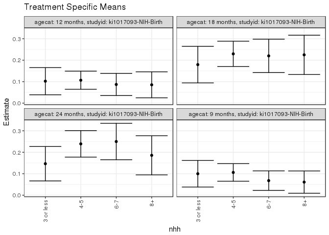

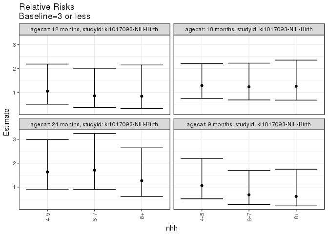

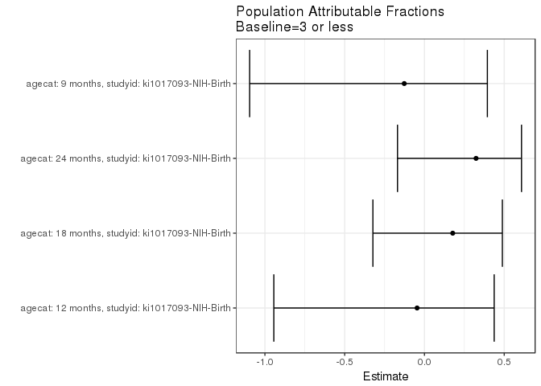

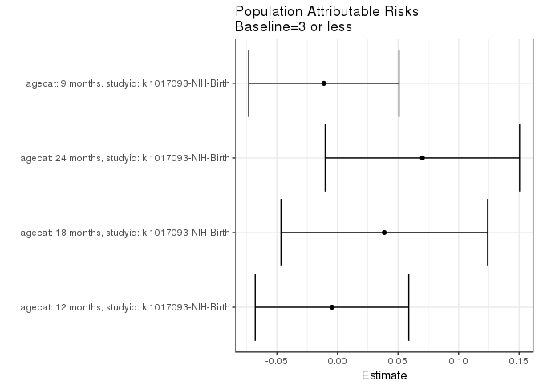

## Data Summary

| agecat | studyid | A | n | nA | nAY0 | nAY1 |
| --- | --- | --- | --- | --- | --- | --- |
| Birth | ki1000108-IRC | 3 or less | 388 | 54 | 53 | 1 |
| Birth | ki1000108-IRC | 4-5 | 388 | 150 | 142 | 8 |
| Birth | ki1000108-IRC | 6-7 | 388 | 103 | 97 | 6 |
| Birth | ki1000108-IRC | 8+ | 388 | 81 | 80 | 1 |
| Birth | ki1000304b-SAS-FoodSuppl | 3 or less | 0 | 0 | 0 | 0 |
| Birth | ki1000304b-SAS-FoodSuppl | 4-5 | 0 | 0 | 0 | 0 |
| Birth | ki1000304b-SAS-FoodSuppl | 6-7 | 0 | 0 | 0 | 0 |
| Birth | ki1000304b-SAS-FoodSuppl | 8+ | 0 | 0 | 0 | 0 |
| Birth | ki1017093-NIH-Birth | 3 or less | 28 | 7 | 7 | 0 |
| Birth | ki1017093-NIH-Birth | 4-5 | 28 | 11 | 11 | 0 |
| Birth | ki1017093-NIH-Birth | 6-7 | 28 | 7 | 7 | 0 |
| Birth | ki1017093-NIH-Birth | 8+ | 28 | 3 | 3 | 0 |
| Birth | ki1017093b-PROVIDE | 3 or less | 0 | 0 | 0 | 0 |
| Birth | ki1017093b-PROVIDE | 4-5 | 0 | 0 | 0 | 0 |
| Birth | ki1017093b-PROVIDE | 6-7 | 0 | 0 | 0 | 0 |
| Birth | ki1017093b-PROVIDE | 8+ | 0 | 0 | 0 | 0 |
| Birth | ki1017093c-NIH-Crypto | 3 or less | 27 | 8 | 8 | 0 |
| Birth | ki1017093c-NIH-Crypto | 4-5 | 27 | 9 | 9 | 0 |
| Birth | ki1017093c-NIH-Crypto | 6-7 | 27 | 7 | 6 | 1 |
| Birth | ki1017093c-NIH-Crypto | 8+ | 27 | 3 | 3 | 0 |
| Birth | ki1148112-LCNI-5 | 3 or less | 0 | 0 | 0 | 0 |
| Birth | ki1148112-LCNI-5 | 4-5 | 0 | 0 | 0 | 0 |
| Birth | ki1148112-LCNI-5 | 6-7 | 0 | 0 | 0 | 0 |
| Birth | ki1148112-LCNI-5 | 8+ | 0 | 0 | 0 | 0 |
| 3 months | ki1000108-IRC | 3 or less | 407 | 58 | 55 | 3 |
| 3 months | ki1000108-IRC | 4-5 | 407 | 156 | 137 | 19 |
| 3 months | ki1000108-IRC | 6-7 | 407 | 106 | 99 | 7 |
| 3 months | ki1000108-IRC | 8+ | 407 | 87 | 80 | 7 |
| 3 months | ki1000304b-SAS-FoodSuppl | 3 or less | 97 | 7 | 5 | 2 |
| 3 months | ki1000304b-SAS-FoodSuppl | 4-5 | 97 | 36 | 32 | 4 |

[output cut: 138 more lines]

## Results Table

### Parameter: TSM

| agecat | studyid | intervention_level | baseline_level | estimate | ci_lower | ci_upper |
| --- | --- | --- | --- | --- | --- | --- |
| 9 months | ki1017093-NIH-Birth | 3 or less | NA | 0.1000000 | 0.0379593 | 0.1620407 |
| 9 months | ki1017093-NIH-Birth | 4-5 | NA | 0.1059908 | 0.0649938 | 0.1469878 |
| 9 months | ki1017093-NIH-Birth | 6-7 | NA | 0.0677966 | 0.0223925 | 0.1132007 |
| 9 months | ki1017093-NIH-Birth | 8+ | NA | 0.0609756 | 0.0091331 | 0.1128182 |
| 12 months | ki1017093-NIH-Birth | 3 or less | NA | 0.1022727 | 0.0389001 | 0.1656453 |
| 12 months | ki1017093-NIH-Birth | 4-5 | NA | 0.1067961 | 0.0645769 | 0.1490153 |
| 12 months | ki1017093-NIH-Birth | 6-7 | NA | 0.0869565 | 0.0354053 | 0.1385077 |
| 12 months | ki1017093-NIH-Birth | 8+ | NA | 0.0853659 | 0.0248248 | 0.1459069 |
| 18 months | ki1017093-NIH-Birth | 3 or less | NA | 0.1794872 | 0.0942302 | 0.2647441 |
| 18 months | ki1017093-NIH-Birth | 4-5 | NA | 0.2295918 | 0.1706494 | 0.2885343 |
| 18 months | ki1017093-NIH-Birth | 6-7 | NA | 0.2201835 | 0.1423094 | 0.2980576 |
| 18 months | ki1017093-NIH-Birth | 8+ | NA | 0.2250000 | 0.1333959 | 0.3166041 |
| 24 months | ki1017093-NIH-Birth | 3 or less | NA | 0.1466667 | 0.0665082 | 0.2268251 |
| 24 months | ki1017093-NIH-Birth | 4-5 | NA | 0.2391304 | 0.1774257 | 0.3008352 |
| 24 months | ki1017093-NIH-Birth | 6-7 | NA | 0.2500000 | 0.1650320 | 0.3349680 |
| 24 months | ki1017093-NIH-Birth | 8+ | NA | 0.1857143 | 0.0945097 | 0.2769189 |

### Parameter: E(Y)

| agecat | studyid | intervention_level | baseline_level | estimate | ci_lower | ci_upper |
| --- | --- | --- | --- | --- | --- | --- |
| 9 months | ki1017093-NIH-Birth | NA | NA | 0.0887574 | 0.0870664 | 0.0904484 |
| 12 months | ki1017093-NIH-Birth | NA | NA | 0.0977597 | 0.0969155 | 0.0986038 |
| 18 months | ki1017093-NIH-Birth | NA | NA | 0.2181425 | 0.2165208 | 0.2197643 |
| 24 months | ki1017093-NIH-Birth | NA | NA | 0.2167832 | 0.2131282 | 0.2204382 |

### Parameter: RR

| agecat | studyid | intervention_level | baseline_level | estimate | ci_lower | ci_upper |
| --- | --- | --- | --- | --- | --- | --- |
| 9 months | ki1017093-NIH-Birth | 4-5 | 3 or less | 1.0599078 | 0.5102140 | 2.201830 |
| 9 months | ki1017093-NIH-Birth | 6-7 | 3 or less | 0.6779661 | 0.2721029 | 1.689207 |
| 9 months | ki1017093-NIH-Birth | 8+ | 3 or less | 0.6097561 | 0.2128419 | 1.746848 |
| 12 months | ki1017093-NIH-Birth | 4-5 | 3 or less | 1.0442287 | 0.5007082 | 2.177742 |
| 12 months | ki1017093-NIH-Birth | 6-7 | 3 or less | 0.8502415 | 0.3606676 | 2.004368 |
| 12 months | ki1017093-NIH-Birth | 8+ | 3 or less | 0.8346883 | 0.3254786 | 2.140554 |
| 18 months | ki1017093-NIH-Birth | 4-5 | 3 or less | 1.2791545 | 0.7454688 | 2.194909 |
| 18 months | ki1017093-NIH-Birth | 6-7 | 3 or less | 1.2267366 | 0.6785105 | 2.217921 |
| 18 months | ki1017093-NIH-Birth | 8+ | 3 or less | 1.2535714 | 0.6705825 | 2.343398 |
| 24 months | ki1017093-NIH-Birth | 4-5 | 3 or less | 1.6304348 | 0.8908845 | 2.983908 |
| 24 months | ki1017093-NIH-Birth | 6-7 | 3 or less | 1.7045455 | 0.8955693 | 3.244277 |
| 24 months | ki1017093-NIH-Birth | 8+ | 3 or less | 1.2662338 | 0.6073080 | 2.640090 |

### Parameter: PAR

| agecat | studyid | intervention_level | baseline_level | estimate | ci_lower | ci_upper |
| --- | --- | --- | --- | --- | --- | --- |
| 9 months | ki1017093-NIH-Birth | 3 or less | NA | -0.0112426 | -0.0733064 | 0.0508212 |
| 12 months | ki1017093-NIH-Birth | 3 or less | NA | -0.0045131 | -0.0678913 | 0.0588652 |
| 18 months | ki1017093-NIH-Birth | 3 or less | NA | 0.0386554 | -0.0466170 | 0.1239277 |
| 24 months | ki1017093-NIH-Birth | 3 or less | NA | 0.0701166 | -0.0101252 | 0.1503583 |

### Parameter: PAF

| agecat | studyid | intervention_level | baseline_level | estimate | ci_lower | ci_upper |
| --- | --- | --- | --- | --- | --- | --- |
| 9 months | ki1017093-NIH-Birth | 3 or less | NA | -0.1266667 | -1.0958581 | 0.3943398 |
| 12 months | ki1017093-NIH-Birth | 3 or less | NA | -0.0461648 | -0.9441684 | 0.4370546 |
| 18 months | ki1017093-NIH-Birth | 3 or less | NA | 0.1772023 | -0.3231511 | 0.4883457 |
| 24 months | ki1017093-NIH-Birth | 3 or less | NA | 0.3234409 | -0.1688957 | 0.6084062 |